# Tarea 2

# Ejercicio 9

¿Las miras telescópicas resultan en puntajes más altos?

1. Usar una prueba basada sólo en rangos. Encontrar el p-valor en tres formas diferentes:
1. encontrar el p-valor exacto, (2) Usar la aproximación normal sin corrección por continuidad y (3) Usar la aproximación normal con la corrección de continuidad.

```r
w<-c(96, 93, 89, 88, 85, 83, 80, 77)
z<-c(92, 92, 89, 96, 82, 79, 80, 78)
dif<-w-z
```

1. p-value exacto

```r
wilcox.test(w,z,alternative = "two.sided",
            paired = FALSE, exact = TRUE, correct = FALSE,
            conf.int = TRUE, conf.level = 0.85,
             digits.rank = Inf)
```

```
##
##  Wilcoxon rank sum test
##
## data:  w and z
## W = 33.5, p-value = 0.8745
## alternative hypothesis: true location shift is not equal to 0
## 85 percent confidence interval:
##  -4.000026  5.999965
## sample estimates:
## difference in location
##              0.1889773
```

(2)Usar la aproximación normal sin corrección por continuidad ¿cómo se le deja la normal sin que se corrija? Me sale igual que con p-value exacto

```r
wilcox.test(w,z,alternative = "two.sided",
            paired = FALSE, exact = FALSE, correct = FALSE,
            conf.int = TRUE, conf.level = 0.85,
             digits.rank = Inf)
```

```
##
##  Wilcoxon rank sum test
##
## data:  w and z
## W = 33.5, p-value = 0.8745
## alternative hypothesis: true location shift is not equal to 0
## 85 percent confidence interval:
##  -4.000026  5.999965
## sample estimates:
## difference in location
##              0.1889773
```

(3)Usar la aproximación normal con la corrección de continuidad

```r
wilcox.test(w,z,alternative = "two.sided",
            paired = FALSE, exact = FALSE, correct = TRUE,
            conf.int = TRUE, conf.level = 0.85,
             digits.rank = Inf)
```

```
##
##  Wilcoxon rank sum test with continuity correction
##
## data:  w and z
## W = 33.5, p-value = 0.9161
## alternative hypothesis: true location shift is not equal to 0
## 85 percent confidence interval:
##  -4.999976  6.000022
## sample estimates:
## difference in location
##              0.1889773
```

```r
shapiro.test(dif)
```

```
##
##  Shapiro-Wilk normality test
##
## data:  dif
## W = 0.83885, p-value = 0.07329
```

Tiene un p-value mayor a 0.05, entonces no rechazamos $H_0$.

```r
#fisher.test(w, z, alternative = "two.sided") la veremos en clase
```

d)Encontrar un intervalo de confianza para la mejora en el puntaje obtenida usando una mira telescópica

```r
library(gmodels)
mejora<-dif
ci(mejora, confidence=0.95)
```

```
##   Estimate   CI lower   CI upper Std. Error
##   0.375000  -2.876358   3.626358   1.375000
```

Tenemos que el intervalo es [-2.876358, 3.626358]

# Ejercicio 10

- 12 escenarios para contar muertos por epidemia por cada medicamento.

```r
# data
medA <- c(41,8,65,28,11,15,73,54,7,50,59,24)
medB <- c(38,14,41,31,8,18,48,32,7,37,42,48)
escen <- 1:12
data <- data.frame(x = cbind(escen,medA,medB))

kable(data, col.names = c("Escenario","Meidicina A","Medicina B"))
```

| Escenario | Meidicina A | Medicina B |
| --- | --- | --- |
| 1 | 41 | 38 |
| 2 | 8 | 14 |
| 3 | 65 | 41 |
| 4 | 28 | 31 |
| 5 | 11 | 8 |
| 6 | 15 | 18 |
| 7 | 73 | 48 |
| 8 | 54 | 32 |
| 9 | 7 | 7 |
| 10 | 50 | 37 |
| 11 | 59 | 42 |
| 12 | 24 | 48 |

## Gráfica de dispersión

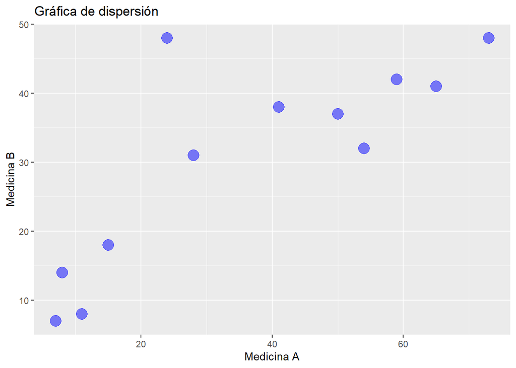

```r
g_ej10_points <- ggplot(data = data, mapping = aes(x = medA, y = medB)) +
                  geom_point(col = "blue", alpha = 0.5, size = 5) + xlab("Medicina A") + ylab("Medicina B") + ggtitle("Gráfica de dispersión")

g_ej10_points
```

## Correlación Spearman y de Kendall

```r
rho_s <-  cor(x = data$x.medA,y = data$x.medB,method = "spearman")
tau_k <- cor(x = data$x.medA,y = data$x.medB,method = "kendall")
```

Vemos que la correlación de Spearman $\rho$, es 0.7880923. Mientras que la correlación de Kendall $\tau$, es 0.6565077.